# Projekt R

Julia Podsadna

2024-12-10

## Uwaga

Raport jest w pełni funkcjonalny tylko w formie włączanej za pomocą RStudio. Wynika to zastosowania shiny.

## Wykorzystane biblioteki

```r
library(DT)
library(ggplot2)
library(dplyr)
library(tidyr)
library(kableExtra)
library(shiny)
library(corrplot)
library(caret)
library(randomForest)
library(plotly)
```

## Wczytanie danych z pliku

```r
batteries <- read.csv("D:/Studia/Zaawansowana Eksploracja Danych/Raporty/mp_batteries.csv")
```

## Czyszczenie danych

```r
batteries <- na.omit(batteries)
```

## Zapewnienie powtarzalności wyników przy każdym uruchomieniu raportu na tych samych danych

Ustawione jest ziarno, które jest używane przy zastosowaniu funkcji z biblioteki randomForest.

```r
set.seed(17)
```

Zbiór danych jest dzielony na dwa podzbiory (dane numeryczne i kategoryczne), ponieważ niektóre funkcje mogą być używanbe tylko na określonym typie danych.

```r
numeric_columns <- batteries %>% select(where(is.numeric))
categorical_columns <- batteries %>% select(where(is.character))
```

## Podsumowanie rozmiaru zbioru i podstawowych statystyk

**Nazwy kolumn:**

```
##  [1] "Battery.ID"                "Battery.Formula"
##  [3] "Working.Ion"               "Formula.Charge"
##  [5] "Formula.Discharge"         "Max.Delta.Volume"
##  [7] "Average.Voltage"           "Gravimetric.Capacity"
##  [9] "Volumetric.Capacity"       "Gravimetric.Energy"
## [11] "Volumetric.Energy"         "Atomic.Fraction.Charge"
## [13] "Atomic.Fraction.Discharge" "Stability.Charge"
## [15] "Stability.Discharge"       "Steps"
## [17] "Max.Voltage.Step"
```

**Liczba wierszy:**

```
## [1] 4351
```

**Liczba kolumn:**

```
## [1] 17
```

## Podsumowanie danych tabeli

**Dane kategoryczne:**

```
##   Battery.ID        Battery.Formula    Working.Ion        Formula.Charge
##  Length:4351        Length:4351        Length:4351        Length:4351
##  Class :character   Class :character   Class :character   Class :character
##  Mode  :character   Mode  :character   Mode  :character   Mode  :character
##  Formula.Discharge
##  Length:4351
##  Class :character
##  Mode  :character
```

**Dane numeryczne:**

| Variable | Min | Max | Mean | Median | SD | NA |
| --- | --- | --- | --- | --- | --- | --- |
| Max.Delta.Volume | 0.0000162 | 2.931932e+02 | 0.3753137 | 0.0420271 | 6.8518375 | 0 |
| Average.Voltage | -7.7547512 | 5.456883e+01 | 3.0831427 | 3.3005818 | 1.8220562 | 0 |
| Gravimetric.Capacity | 5.1765430 | 2.557627e+03 | 158.2908894 | 130.6909797 | 164.9136411 | 0 |
| Volumetric.Capacity | 24.0790699 | 7.619191e+03 | 610.6240987 | 507.0312049 | 563.8531258 | 0 |
| Gravimetric.Energy | -583.5458444 | 5.926950e+03 | 444.1063802 | 401.7876573 | 351.0481297 | 0 |
| Volumetric.Energy | -2208.0745659 | 1.830590e+04 | 1664.0484137 | 1463.7877150 | 1297.7985678 | 0 |
| Atomic.Fraction.Charge | 0.0000000 | 9.090909e-01 | 0.0398558 | 0.0000000 | 0.0885604 | 0 |
| Atomic.Fraction.Discharge | 0.0074074 | 9.933333e-01 | 0.1590772 | 0.1428571 | 0.1203743 | 0 |
| Stability.Charge | 0.0000000 | 6.487098e+00 | 0.1425666 | 0.0731920 | 0.3782776 | 0 |
| Stability.Discharge | 0.0000000 | 6.277809e+00 | 0.1220717 | 0.0487845 | 0.3523182 | 0 |
| Steps | 1.0000000 | 6.000000e+00 | 1.1670880 | 1.0000000 | 0.4637496 | 0 |
| Max.Voltage.Step | 0.0000000 | 2.696069e+01 | 0.1502897 | 0.0000000 | 0.6300680 | 0 |

## Pełna tabela

|  | Battery.ID | Battery.Formula | Working.Ion | Formula.Charge | Formula.Discharge | Max.Delta.Volume | Average.Voltage | Gravimetric.Capacity | Volumetric.Capacity | Gravimetric.Energy | Volumetric.Energy | Atomic.Fraction.Charge | Atomic.Fraction.Discharge | Stability.Charge | Stability.Discharge | Steps | Max.Voltage.Step |
| --- | --- | --- | --- | --- | --- | --- | --- | --- | --- | --- | --- | --- | --- | --- | --- | --- | --- |
| 1 | mp-30_Al | Al0-2Cu | Al | Cu | Al2Cu | 3.043399166099431 | 0.08903311500000004 | 1368.480552344797 | 5562.790129820172 | 121.8400863921779 | 495.2725333491446 | 0 | 0.6666666666666666 | 0 | 0 | 1 | 0 |
| 2 | mp-1022721_Al | Al1-3Cu | Al | AlCu | Al3Cu | 1.243652762037662 | -0.02158634499999993 | 1112.936545960678 | 4418.979753458019 | -24.02423224421548 | -95.38962150615946 | 0.5 | 0.75 | 0.07406123800000142 | 0.09624583499999995 | 1 | 0 |
| 3 | mp-8637_Al | Al0-5Mo | Al | Mo | Al5Mo | 4.762574292667813 | 0.1227568450000002 | 1741.504157810485 | 7175.701747409025 | 213.7815559671976 | 880.8665071729203 | 0 | 0.8333333333333334 | 0.4114600999999993 | 0.0452119541666649 | 1 | 0 |
| 4 | mp-129_Al | Al0-12Mo | Al | Mo | Al12Mo | 12.72389306460614 | 0.04312143250000015 | 2298.810764427435 | 7346.232301868708 | 99.12801320853136 | 316.7800603343522 | 0 | 0.9230769230769231 | 0 | 0.01144559461539085 | 1 | 0 |
| 5 | mp-91_Al | Al0-12W | Al | W | Al12W | 12.49459771046897 | 0.02923420583333325 | 1900.745128833013 | 7332.71861237705 | 55.56677433300982 | 214.3662052321445 | 0 | 0.9230769230769231 | 0 | 0 | 1 | 0 |
| 6 | mp-1055908_Al | Al0-12Mn | Al | Mn | MnAl12 | 18.23615633776148 | 0.03973135916666667 | 2547.692800134188 | 7592.91608289565 | 101.2232976884621 | 301.6768760118869 | 0 | 0.9230769230769231 | 0.145464322068964 | 0 | 1 | 0 |
| 7 | mp-2658_Al | Al0-1Fe | Al | Fe | AlFe | 0.7711538538175469 | 0.47172873 | 970.7570157482313 | 5622.356217978021 | 457.9339741775032 | 2652.226958314375 | 0 | 0.5 | 0.7613994000000002 | 0 | 1 | 0 |
| 8 | mp-16722_Al | Al1-10.25V | Al | Al10V | Al41V4 | 0.002710803352354851 | -0.01558272333334069 | 61.37701219331353 | 176.4151307950982 | -0.9564210000354828 | -2.749028174995126 | 0.9090909090909091 | 0.9111111111111111 | 0.01180966318181742 | 0.01258607444444415 | 1 | 0 |
| 9 | mp-998981_Al | Al1-3Ti | Al | TiAl | TiAl3 | 0.9562924420330603 | 0.160244985 | 1248.40361541512 | 4248.421059693514 | 200.0504186261416 | 680.7881689842711 | 0.5 | 0.75 | 0.1415911549999995 | 0.0244962150000001 | 1 | 0 |
| 10 | mp-8633_K | K0-3Cr | K | Cr | K3Cr | 15.80293625795156 | -0.7487069369999995 | 474.9481274024708 | 667.5592873001001 | -355.5969577013894 | -499.8062692603606 | 0 | 0.75 | 0.4025263400000014 | 0.6621617877500001 | 1 | 0 |

[output cut: 4341 more lines]

## Szczegółowa analiza wartości atrybutów

Jeśli histogram się nie wyświetla, należy zmienić szerokość przedziału.  
Dzięki histogramom można zobaczyć, jakie wartości dla danego parametru baterii występują najczęściej.

Shiny applications not supported in static R Markdown documents

## Korelacje między zmiennymi

Jeśli histogram się nie wyświetla, należy zmienić szerokość przedziału.  
Dzięki histogramom można zobaczyć, jakie wartości dla danego parametru baterii występują najczęściej z podziałem kolorystycznym ze względu na jon roboczy.

Shiny applications not supported in static R Markdown documents

## Macierz korelacji

Macierz korelacji przedstawia jak bardzo parametry są powiązane ze sobą nawzajem.

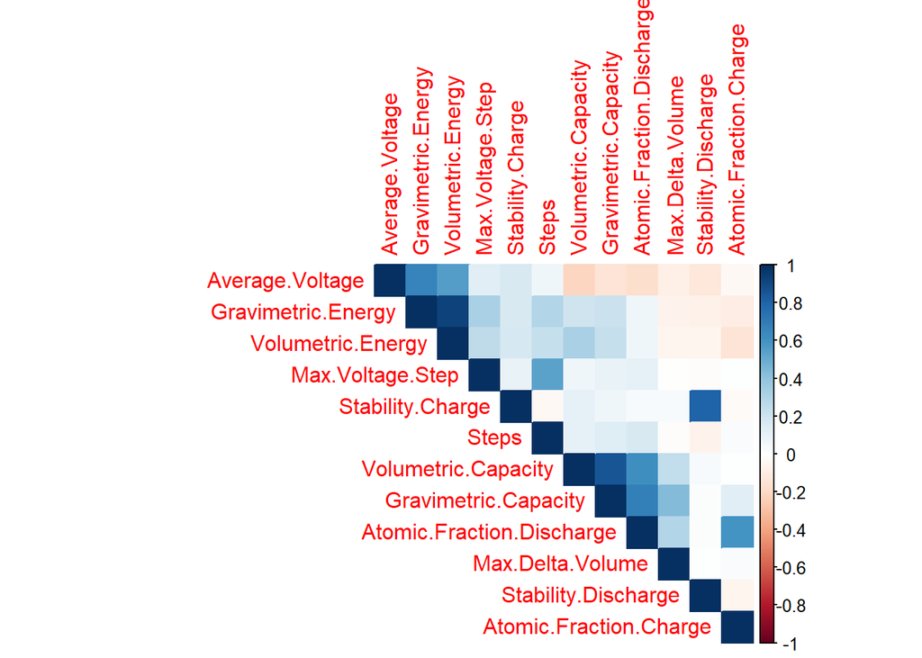

**Gravimetric.Capacity** jest silnie skorelowana z **Volumetric.Capacity**. Im większa pojemność objętościowa, tym większa pojemność wagowa.  
**Atomic.Fraction.Discharge** ma silną korelację z **Atomic.Fraction.Charge**, co sugeruje, że te dwie zmienne są ze sobą powiązane.  
**Average.Voltage** i **Max.Delta.Volume** są lekko negatywnie skorelowane, co może wskazywać, że wyższe wartości napięcia średniego mogą być związane z mniejszymi wartościami zmiany objętości.  
**Average.Voltage** i **Volumetric.Capacity** również mają negatywną korelację, co może sugerować, że wyższe napięcie średnie wiąże się z mniejszą pojemnością objętościową.  
Wiele zmiennych, takich jak **Steps**, wykazuje słabe lub znikome korelacje z innymi parametrami. Na przykład **Stability.Charge** jest słabo skorelowane z **Steps** oraz z **Max.Delta.Volume**, co oznacza, że te zmienne mają ograniczony wpływ na siebie nawzajem.  
**Gravimetric.Energy** jest bardzo silnie skorelowane z **Volumetric.Energy**, wskazując na to, że zmiany w energii wagowej są podobne do zmian w energii objętościowej.  
**Stability.Discharge** i **Stability.Charge** mają wyraźną korelację.

## Podsumowanie najważniejszych trendów w badaniu materiałów do baterii

**Najczęściej występujące jony robocze:**

Shiny applications not supported in static R Markdown documents

Najpopularniejszym jonem roboczym w bateriach jest **lit** i zdecydowanie przewyższa on popularnością pozostałe pierwiastki. Kolejnymi istostnymi pierwiastkami są **wapń**, **magnez**, **cynk** oraz **sód**.  
Kolejnymi pierwiastkami, które występują zbliżoną ilość razy jest **potas**, **glin** i **itr**.  
Najrzadziej występujące w zbiorze są **rubid** i **cez**.

**Lit (Li)** należy do metali alkalicznych, które charakteryzują się wyjątkową reaktywnością, szczególnie w kontakcie z wodą, oraz niską gęstością. Jest jednym z najlżejszych metali, co czyni go idealnym do zastosowań w bateriach, gdzie jego niewielki ciężar ma duże znaczenie.

**Wapń (Ca)** i **magnez (Mg)** są metalami ziem alkalicznych. Metale te są stosunkowo reaktywne, a ich związki są szeroko stosowane w różnych dziedzinach przemysłu, w tym w technologii akumulatorów. Magnez, podobnie jak lit, jest lekki, co sprzyja stosowaniu go w energetyce, szczególnie w kontekście akumulatorów.

**Cynk (Zn)** to metal przejściowy, który jest szeroko wykorzystywany w ogniwach galwanicznych oraz w procesach ochrony przed korozją. Jest mniej reaktywny niż metale alkaliczne, ale również posiada dobre właściwości przewodzące.

**Sód (Na)**, podobnie jak lit, należy do metali alkalicznych i jest stosunkowo reaktywny. Jest często wykorzystywany w ogniwach sodowych, które stanowią alternatywę dla akumulatorów litowych.

**Potas (K)**, również metal alkaliczny, jest bardziej reaktywny niż sód i lit, ale wciąż znajduje zastosowanie w badaniach nad nowymi rodzajami baterii.

**Glin (Al)** to metal przejściowy, który jest powszechnie stosowany w stopach metali, a także w technologii akumulatorów, zwłaszcza w kontekście konstrukcji obudów ogniw.

**Itr (Y)** należy do metali ziem rzadkich. Chociaż nie jest szeroko stosowany w technologii akumulatorów, jego unikalne właściwości, takie jak odporność na korozję, sprawiają, że znajduje zastosowanie w niektórych zaawansowanych materiałach.

**Rubid (Rb)** i **cez** to metale alkaliczne, które występują w przyrodzie w niewielkich ilościach. Mimo że są stosunkowo mało popularne w technologii baterii, ich właściwości chemiczne mogą znaleźć zastosowanie w bardzo specyficznych, innowacyjnych rozwiązaniach energetycznych.

Wszystkie te metale mają znaczenie w kontekście technologii bateryjnych, ponieważ ich właściwości elektrochemiczne umożliwiają magazynowanie energii w postaci jonów, co jest podstawą działania akumulatorów.

**Najczęściej występujące składy chemiczne baterii:**

Shiny applications not supported in static R Markdown documents

Wiele z tych formuł to związki litowe, które są powszechnie stosowane w akumulatorach litowo-jonowych. Oprócz litowych związków, w zbiorze pojawiają się również formuły z innymi metalami, takimi jak magnez, cynk, wapń czy sód.

Formuły te obejmują różnorodne tlenki, fosforany, fluorowce i inne związki, które mają na celu poprawę właściwości elektrochemicznych materiałów stosowanych w akumulatorach, takich jak ich pojemność, stabilność oraz żywotność. Zawarte w zbiorze związki mogą mieć zastosowanie w rozwoju nowych technologii magazynowania energii, oferując potencjalne korzyści, takie jak wyższa efektywność czy obniżenie kosztów produkcji.

## Przewidywanie jonu roboczego na podstawie pozostałych parametrów (wykluczając formułę baterii i chemiczny skład)

**Macierz pomyłek oraz statystki predykcji:**

```
## Confusion Matrix and Statistics
##
##           Reference
## Prediction  Al  Ca  Cs   K  Li  Mg  Na  Rb   Y  Zn
##         Al  10   0   0   0   0   0   0   0   0   0
##         Ca   2  53   0   1  45  18   4   2   2   2
##         Cs   0   0   0   0   0   0   0   0   0   0
##         K    0   0   3   6   1   0   5   4   0   0
##         Li   1   9   2  12 438   9  44   3   4   3
##         Mg   1  15   0   0   1  41   1   0   1   5
##         Na   0   0   0   2   1   0   7   0   0   0
##         Rb   0   0   1   0   0   0   0   1   0   0
##         Y    1   0   0   0   0   0   0   0   8   0
##         Zn   4  10   0   0   2  16   0   0   3  63
##
## Overall Statistics
##
##                Accuracy : 0.7232
##                  95% CI : (0.6921, 0.7527)
##     No Information Rate : 0.5629
##     P-Value [Acc > NIR] : < 2.2e-16
##
##                   Kappa : 0.5575
##
##  Mcnemar's Test P-Value : NA
##
## Statistics by Class:
##
##                      Class: Al Class: Ca Class: Cs Class: K Class: Li Class: Mg
## Sensitivity            0.52632   0.60920   0.00000  0.28571    0.8975   0.48810
## Specificity            1.00000   0.90256   1.00000  0.98463    0.7704   0.96935
## Pos Pred Value         1.00000   0.41085       NaN  0.31579    0.8343   0.63077
## Neg Pred Value         0.98950   0.95393   0.99308  0.98231    0.8538   0.94638
## Prevalence             0.02191   0.10035   0.00692  0.02422    0.5629   0.09689
## Detection Rate         0.01153   0.06113   0.00000  0.00692    0.5052   0.04729
## Detection Prevalence   0.01153   0.14879   0.00000  0.02191    0.6055   0.07497
## Balanced Accuracy      0.76316   0.75588   0.50000  0.63517    0.8340   0.72872
##                      Class: Na Class: Rb Class: Y Class: Zn
## Sensitivity           0.114754  0.100000 0.444444   0.86301
## Specificity           0.996278  0.998833 0.998822   0.95592
## Pos Pred Value        0.700000  0.500000 0.888889   0.64286
## Neg Pred Value        0.936989  0.989595 0.988345   0.98700
## Prevalence            0.070358  0.011534 0.020761   0.08420
## Detection Rate        0.008074  0.001153 0.009227   0.07266
## Detection Prevalence  0.011534  0.002307 0.010381   0.11303
## Balanced Accuracy     0.555516  0.549417 0.721633   0.90947
```

**Macierz pomyłek** pokazuje liczbę poprawnie oraz błędnie zaklasyfikowanych przypadków dla każdej klasy. Na przykład model poprawnie sklasyfikował 10 przypadków jako Al oraz 53 jako Ca, ale popełnił również błędy, takie jak zaklasyfikowanie Li jako Ca lub Mg.

**Dokładność (Accuracy)**: 0,7232, co oznacza, że model poprawnie sklasyfikował około 72,32% przypadków.  
**Przedział ufności 95% (95% CI)**: (0,6921, 0,7527), co oznacza, że z 95% pewnością dokładność mieści się w tym przedziale.  
**Brak informacji o klasie (No Information Rate)**: 0,5629, co wskazuje, że większość przypadków należy do jednej klasy, a model bez używania żadnej informacji o cechach mógłby uzyskać dokładność na poziomie 56,29%.  
**Wartość P dla dokładności większej niż NIR (P-Value [Acc > NIR])**: < 2.2e-16, co sugeruje, że wyniki modelu są statystycznie istotne, ponieważ dokładność modelu jest znacznie wyższa niż dokładność wynikająca z losowego zgadywania.  
**Kappa**: 0,5575, co wskazuje na umiarkowaną zgodność między przewidywaniami modelu a rzeczywistymi klasami (0 oznacza brak zgody, a 1 oznacza pełną zgodność).

**Ważność zmiennych:**

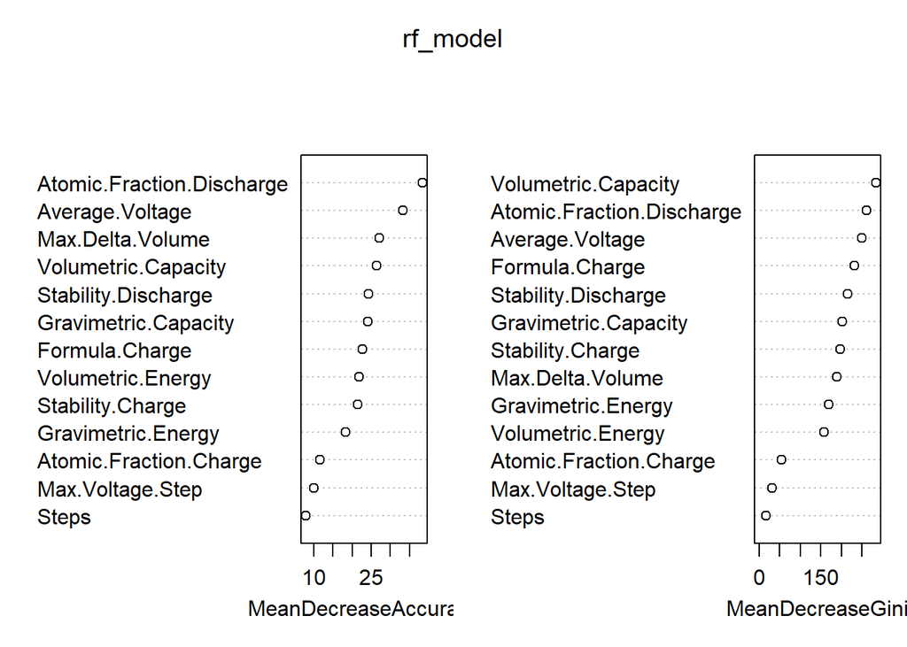

|  | MeanDecreaseAccuracy | MeanDecreaseGini |
| --- | --- | --- |
| Formula.Charge | 22.65630342797686 | 231.9615137028212 |
| Max.Delta.Volume | 27.12722159688952 | 189.2590234190978 |
| Average.Voltage | 33.33888758085003 | 250.7253073899117 |
| Gravimetric.Capacity | 24.03875934564769 | 201.7403940784951 |
| Volumetric.Capacity | 26.44643101915166 | 284.7689814560304 |
| Gravimetric.Energy | 18.34253305784794 | 169.2065718567784 |
| Volumetric.Energy | 21.87643259717946 | 158.5781361331054 |
| Atomic.Fraction.Charge | 11.57662474513815 | 54.08823254955626 |
| Atomic.Fraction.Discharge | 38.44126104512019 | 262.1578690373828 |
| Stability.Charge | 21.53325919818998 | 197.2358561490083 |

[output cut: 3 more lines]

**MeanDecreaseAccuracy**: Ta miara pokazuje, jak duży wpływ na dokładność modelu ma zmiana wartości danej zmiennej. Im wyższa wartość, tym bardziej istotna jest dana zmienna w przewidywaniu klasy. Wysokie wartości wskazują, że usunięcie tej zmiennej z modelu spowoduje znaczące pogorszenie dokładności.  
**MeanDecreaseGini**: To miara wpływu zmiennej na czystość podziału w drzewie decyzyjnym. Wysokie wartości wskazują, że zmienna pomaga w podziale danych na bardziej jednorodne klasy (niższa wartość Gini oznacza lepszy podział).

**Tabela z dopisanym przewidywanym jonem roboczym:**

|  | Predicted.Working.Ion | Battery.ID | Battery.Formula | Working.Ion | Formula.Charge | Formula.Discharge | Max.Delta.Volume | Average.Voltage | Gravimetric.Capacity | Volumetric.Capacity | Gravimetric.Energy | Volumetric.Energy | Atomic.Fraction.Charge | Atomic.Fraction.Discharge | Stability.Charge | Stability.Discharge | Steps | Max.Voltage.Step |
| --- | --- | --- | --- | --- | --- | --- | --- | --- | --- | --- | --- | --- | --- | --- | --- | --- | --- | --- |
| 1 | Al | mp-30_Al | Al0-2Cu | Al | Cu | Al2Cu | 3.043399166099431 | 0.08903311500000004 | 1368.480552344797 | 5562.790129820172 | 121.8400863921779 | 495.2725333491446 | 0 | 0.6666666666666666 | 0 | 0 | 1 | 0 |
| 2 | Mg | mp-1022721_Al | Al1-3Cu | Al | AlCu | Al3Cu | 1.243652762037662 | -0.02158634499999993 | 1112.936545960678 | 4418.979753458019 | -24.02423224421548 | -95.38962150615946 | 0.5 | 0.75 | 0.07406123800000142 | 0.09624583499999995 | 1 | 0 |
| 3 | Al | mp-8637_Al | Al0-5Mo | Al | Mo | Al5Mo | 4.762574292667813 | 0.1227568450000002 | 1741.504157810485 | 7175.701747409025 | 213.7815559671976 | 880.8665071729203 | 0 | 0.8333333333333334 | 0.4114600999999993 | 0.0452119541666649 | 1 | 0 |
| 4 | Al | mp-129_Al | Al0-12Mo | Al | Mo | Al12Mo | 12.72389306460614 | 0.04312143250000015 | 2298.810764427435 | 7346.232301868708 | 99.12801320853136 | 316.7800603343522 | 0 | 0.9230769230769231 | 0 | 0.01144559461539085 | 1 | 0 |
| 5 | Al | mp-91_Al | Al0-12W | Al | W | Al12W | 12.49459771046897 | 0.02923420583333325 | 1900.745128833013 | 7332.71861237705 | 55.56677433300982 | 214.3662052321445 | 0 | 0.9230769230769231 | 0 | 0 | 1 | 0 |
| 6 | Al | mp-1055908_Al | Al0-12Mn | Al | Mn | MnAl12 | 18.23615633776148 | 0.03973135916666667 | 2547.692800134188 | 7592.91608289565 | 101.2232976884621 | 301.6768760118869 | 0 | 0.9230769230769231 | 0.145464322068964 | 0 | 1 | 0 |
| 7 | Y | mp-2658_Al | Al0-1Fe | Al | Fe | AlFe | 0.7711538538175469 | 0.47172873 | 970.7570157482313 | 5622.356217978021 | 457.9339741775032 | 2652.226958314375 | 0 | 0.5 | 0.7613994000000002 | 0 | 1 | 0 |
| 8 | Al | mp-16722_Al | Al1-10.25V | Al | Al10V | Al41V4 | 0.002710803352354851 | -0.01558272333334069 | 61.37701219331353 | 176.4151307950982 | -0.9564210000354828 | -2.749028174995126 | 0.9090909090909091 | 0.9111111111111111 | 0.01180966318181742 | 0.01258607444444415 | 1 | 0 |
| 9 | Al | mp-998981_Al | Al1-3Ti | Al | TiAl | TiAl3 | 0.9562924420330603 | 0.160244985 | 1248.40361541512 | 4248.421059693514 | 200.0504186261416 | 680.7881689842711 | 0.5 | 0.75 | 0.1415911549999995 | 0.0244962150000001 | 1 | 0 |
| 10 | K | mp-8633_K | K0-3Cr | K | Cr | K3Cr | 15.80293625795156 | -0.7487069369999995 | 474.9481274024708 | 667.5592873001001 | -355.5969577013894 | -499.8062692603606 | 0 | 0.75 | 0.4025263400000014 | 0.6621617877500001 | 1 | 0 |

[output cut: 4341 more lines]